# Vargas_Project_01

Juan Vargas

10/9/2022

# Reproducible Reporting

## Load libraries

```r
library(tidyverse)
library(kableExtra)
library(DT)
```

## Funcitons

```r
freezer = function(){
  setwd('C:\\Users\\Juan\\Documents\\Vargas_Project_01\\Raw Data')
}

fridge = function(){
  setwd('C:\\Users\\Juan\\Documents\\Vargas_Project_01\\Processed Data')
}

reports = function(){
  setwd('C:\\Users\\Juan\\Documents\\Vargas_Project_01\\Reports')
}
```

## Report

Exposure to high levels of lead may cause anemia, weakness, and kidney and brain damage. Lead can cross the placental barrier, which means pregnant women who are exposed to lead also expose their unborn child. Lead can damage a developing baby’s nervous system.

The data was collected by a team of researchers led by the CDC, in which investigates children from the ages of 3 and 15 in El Paso living in different distances from a lead-emitting ore smelter. We will be analyzing the lead dataset to determine if living near or far from the smelter affects IQ.

```r
freezer()

dt=
  read_csv('lead-iq-01.csv')
datatable(dt)
```

|  | Smelter | IQ |
| --- | --- | --- |
| 1 | Far | 70 |
| 2 | Far | 85 |
| 3 | Far | 86 |
| 4 | Far | 76 |
| 5 | Far | 96 |
| 6 | Far | 94 |
| 7 | Far | 115 |
| 8 | Far | 97 |
| 9 | Far | 128 |
| 10 | Far | 999 |

[output cut: 114 more lines]

```r
summary(dt)
```

```
##    Smelter                IQ
##  Length:124         Min.   : 46.00
##  Class :character   1st Qu.: 81.50
##  Mode  :character   Median : 91.00
##                     Mean   : 98.34
##                     3rd Qu.: 99.25
##                     Max.   :999.00
```

Changing the outlier

```r
dt %>% filter(IQ > 900)
```

```
## # A tibble: 1 x 2
##   Smelter    IQ
##   <chr>   <dbl>
## 1 Far       999
```

```r
# Its only 1 row, so we can work on it as if theres more

dt$IQ = ifelse(dt$IQ == 999, 99,dt$IQ)
```

```r
fridge()

write_csv(dt,'lead-iq-01-outlier_removed.csv')
```

## Plot, Histogram

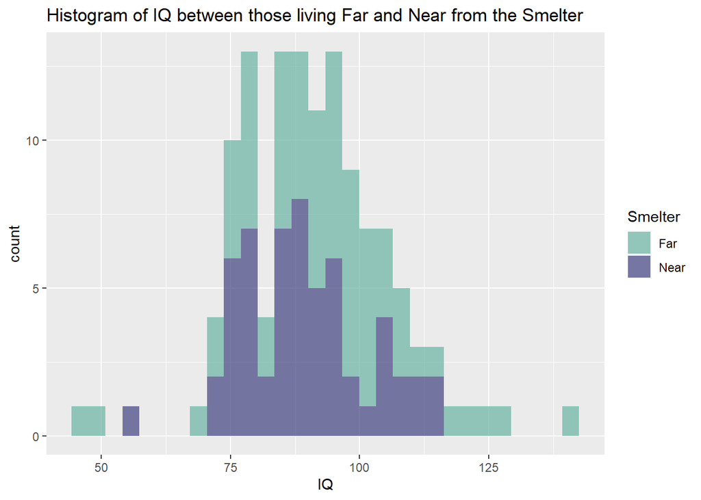

```r
dt %>%
  ggplot() +
    geom_histogram(aes(x = IQ, fill = Smelter), alpha = 0.7) +
    scale_fill_manual(values = c("#69b3a2", "#404080")) +
  ggtitle('Histogram of IQ between those living Far and Near from the Smelter') +
  labs('Distance')
```

Plotted is the histogram of both groups overlapped. We can see those far have a wide range compared to those neat the smelter.

## Summary table

The following table is the summary statistics of the data.

```r
dt %>%
  group_by(Smelter) %>%
    summarize(
      'N'= n(),
      'Mean IQ' = mean(IQ),
      'Median IQ' = median(IQ),
      '10% IQ Quantile' = quantile(IQ, probs = 0.10),
      '90% IQ Quantile' = quantile(IQ, probs = 0.90),
      'Max' = max(IQ),
      'Min' = min(IQ)
    ) %>%
  kableExtra::kbl()%>%
  kable_classic_2(full_width = F)
```

| Smelter | N | Mean IQ | Median IQ | 10% IQ Quantile | 90% IQ Quantile | Max | Min |
| --- | --- | --- | --- | --- | --- | --- | --- |
| Far | 67 | 92.68657 | 93 | 76.0 | 109.2 | 141 | 46 |
| Near | 57 | 89.19298 | 88 | 75.6 | 106.4 | 115 | 56 |

Following a t-test will be performed to determine if theres a statistical difference of IQ between of those living far and near from the smelter. Will be using an alpha of 5%

## T-test

```r
t.test(IQ ~ Smelter, data = dt)
```

```
##
##  Welch Two Sample t-test
##
## data:  IQ by Smelter
## t = 1.38, df = 120.62, p-value = 0.1702
## alternative hypothesis: true difference in means between group Far and group Near is not equal to 0
## 95 percent confidence interval:
##  -1.518663  8.505833
## sample estimates:
##  mean in group Far mean in group Near
##           92.68657           89.19298
```